# Assignment 4

### Week 4 Assignment Submission - K.Maadhu

```python
import pandas as pd
import numpy as np
import os
import matplotlib.pyplot as plt
%matplotlib inline
from sklearn.preprocessing import StandardScaler
from sklearn.cluster import KMeans, AgglomerativeClustering
```

**Read the driver_data.csv file into a dataframe**

```python
os.chdir(r'C:\Maadhu\Jigsaw\Assignments\UC\AA&ML\Week 4')
```

```python
driver_df = pd.read_csv('driver_data.csv')
```

```python
driver_df.shape
```

```
(4000, 2)
```

```python
driver_df.head()
```

|  | Distance_Feature | Speeding_Feature |
| --- | --- | --- |
| 0 | 71.24 | 28 |
| 1 | 52.53 | 25 |
| 2 | 64.54 | 27 |
| 3 | 55.69 | 22 |
| 4 | 54.58 | 25 |

#### Apply K-Means algorithm to identify the clusters

Scale the input data using Standard Scaling and transform the input values

```python
scaled_data = StandardScaler().fit(driver_df).transform(driver_df)
```

```python
type(scaled_data)
```

```
numpy.ndarray
```

```python
scaled_data[:10,]
```

```
array([[-0.0898104 ,  1.26061251],
       [-0.43977285,  1.04174351],
       [-0.215131  ,  1.18765617],
       [-0.38066642,  0.8228745 ],
       [-0.40142849,  1.04174351],
       [-0.63841535, -0.05260152],
       [-0.32548795,  0.67696183],
       [-0.44931218, -0.19851419],
       [-0.83780604,  1.69835052],
       [-0.59352439,  0.6040055 ]])
```

Create a variable to store the Sum of Squares which is the output of the KMeans clustering model.

Run the model for 10 times and get the output value of SSQ represented by 'Inertia'.

```python
ssq = []
```

```python
for K in range(1,11):
    kmeans_model = KMeans(n_clusters = K, random_state=2).fit(scaled_data)
    ssq.append(kmeans_model.inertia_)
```

The above code will execute the KMeans model 10 times for the scaled data provided as input

The output value of 'Inertia' is then added to the list variable ssq and displayed below

```python
ssq
```

```
[7999.999999999998,
 3911.9263904284167,
 1756.5445821314272,
 739.1534508645581,
 619.4037594867996,
 502.03685490351074,
 438.64433211865617,
 374.4370999309646,
 337.14373478361546,
 305.62536455853166]
```

**Based on the above output, we see that the optimal cluster is 4. We plot all the outputs values into a Scree plot visual below.**

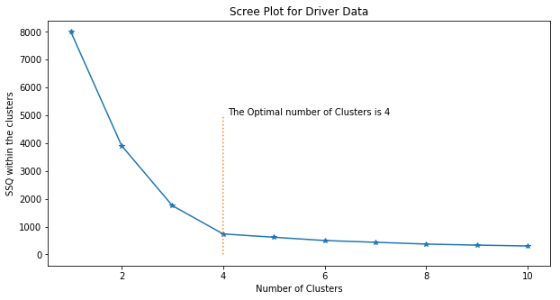

```python
plt.figure(figsize=(10,5))
plt.plot(range(1,11), ssq, marker = '*')
plt.title('Scree Plot for Driver Data')
plt.xlabel('Number of Clusters')
plt.ylabel('SSQ within the clusters')
plt.plot([4]*5000, range(1,5001), ':')
plt.text(4.1, 5001, 'The Optimal number of Clusters is 4')
plt.show()
```

**Run the model again with the cluster value of 4 and get the output**

```python
km = KMeans(n_clusters=4, random_state=2).fit(scaled_data)
```

```python
km.inertia_
```

```
739.1534508645581
```

**Predict which drivers will be categorized into which of the 4 clusters**

```python
predicted_cluster = km.predict(scaled_data)
```

```python
predicted_cluster[:10]
```

```
array([3, 3, 3, 3, 3, 1, 3, 1, 3, 3])
```

The number of drivers categorized into each cluster in given below

```python
count_df = pd.DataFrame(list(np.unique(predicted_cluster, return_counts=True))).T
count_df.columns=['Cluster ID', 'Driver Count']
count_df
```

|  | Cluster ID | Driver Count |
| --- | --- | --- |
| 0 | 0 | 104 |
| 1 | 1 | 2774 |
| 2 | 2 | 695 |
| 3 | 3 | 427 |

Based on the above output, we understand that most of the drivers are present in the 2nd cluster identified by 1.

Silhouette Score calculation for K-Means approach

```python
from sklearn.metrics import silhouette_score
```

```python
silhouette_score(scaled_data, predicted_cluster)
```

```
0.7843727073779272
```

**The Silhouette score for the driver dataset using the K-Means clustering algorithm is 0.78.**

Assignment of the above clusters to the actual drivers based on the index value is given below.

```python
driver_df['KM Cluster ID'] = pd.Series(predicted_cluster, index=driver_df.index)
driver_df.index.name = 'Driver ID'
driver_df.head(10)
```

| Driver ID | Distance_Feature | Speeding_Feature | KM Cluster ID |
| --- | --- | --- | --- |
| 0 | 71.24 | 28 | 3 |
| 1 | 52.53 | 25 | 3 |
| 2 | 64.54 | 27 | 3 |
| 3 | 55.69 | 22 | 3 |
| 4 | 54.58 | 25 | 3 |
| 5 | 41.91 | 10 | 1 |
| 6 | 58.64 | 20 | 3 |
| 7 | 52.02 | 8 | 1 |
| 8 | 31.25 | 34 | 3 |
| 9 | 44.31 | 19 | 3 |

#### Apply Hierarchical Clustering using Scikit-Learn for the same driver dataset

Use the above created 'scaled_data' variable, as that's not changed and we need a scaled input for this model as well.

```python
scaled_data[:10]
```

```
array([[-0.0898104 ,  1.26061251],
       [-0.43977285,  1.04174351],
       [-0.215131  ,  1.18765617],
       [-0.38066642,  0.8228745 ],
       [-0.40142849,  1.04174351],
       [-0.63841535, -0.05260152],
       [-0.32548795,  0.67696183],
       [-0.44931218, -0.19851419],
       [-0.83780604,  1.69835052],
       [-0.59352439,  0.6040055 ]])
```

```python
scaled_data.shape
```

```
(4000, 2)
```

**Using Scipy create a dendrogram for the above dataset input.**

```python
from scipy.cluster.hierarchy import linkage, dendrogram, set_link_color_palette
```

Here we create the linkage for the hierarchical clustering using the 'Ward' method and distance measurement of 'Euclidean'.

Create the linkage and generate the dendrogram using the Brown colour.

```python
link = linkage(scaled_data, method='ward', metric='euclidean')
```

```python
set_link_color_palette(['brown'])
```

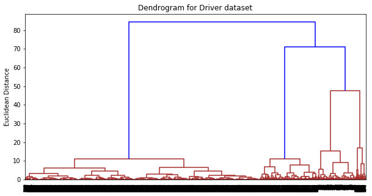

```python
plt.figure(figsize=(10,5))
dnd = dendrogram(link)
plt.title('Dendrogram for Driver dataset')
plt.ylabel('Euclidean Distance')
plt.show()
```

**Now let's implement Agglomerative clustering to our dataset**

```python
agg_model_output = AgglomerativeClustering(n_clusters=2).fit(scaled_data)
```

```python
np.unique(agg_model_output.labels_, return_counts=True)
```

```
(array([0, 1], dtype=int64), array([1248, 2752], dtype=int64))
```

Based on this clustering approach, we see that there are 1248 drivers in Cluster 0 and 2752 drivers in Cluster 1.

Silhouette Score calculation for Agglomerative approach

```python
silhouette_score(scaled_data, agg_model_output.labels_)
```

```
0.6422495198401666
```

**The Silhouette score for the driver dataset using the Agglomerative clustering algorithm is 0.64.**

### Based on the above results, we observe that for the given driver dataset, the K-Means algorithm has provided a better output and the optimum number of clusters is 4.

The input driver dataset with the 2 Cluster ID columns is given below

```python
driver_df['Agglo Cluster ID'] = pd.Series(agg_model_output.labels_, index=driver_df.index)
driver_df.head(10)
```

| Driver ID | Distance_Feature | Speeding_Feature | KM Cluster ID | Agglo Cluster ID |
| --- | --- | --- | --- | --- |
| 0 | 71.24 | 28 | 3 | 0 |
| 1 | 52.53 | 25 | 3 | 0 |
| 2 | 64.54 | 27 | 3 | 0 |
| 3 | 55.69 | 22 | 3 | 0 |
| 4 | 54.58 | 25 | 3 | 0 |
| 5 | 41.91 | 10 | 1 | 1 |
| 6 | 58.64 | 20 | 3 | 0 |
| 7 | 52.02 | 8 | 1 | 1 |
| 8 | 31.25 | 34 | 3 | 0 |
| 9 | 44.31 | 19 | 3 | 0 |

### Question 2 (Optional)

```python
stocks_df = pd.read_csv('company_stocks.csv')
```

```python
stocks_df.head()
```

|  | Unnamed: 0 | 2010-01-04 | 2010-01-05 | 2010-01-06 | 2010-01-07 | 2010-01-08 | 2010-01-11 | 2010-01-12 | 2010-01-13 | 2010-01-14 | ... | 2013-10-16 | 2013-10-17 | 2013-10-18 | 2013-10-21 | 2013-10-22 | 2013-10-23 | 2013-10-24 | 2013-10-25 | 2013-10-28 | 2013-10-29 |
| --- | --- | --- | --- | --- | --- | --- | --- | --- | --- | --- | --- | --- | --- | --- | --- | --- | --- | --- | --- | --- | --- |
| 0 | AIG | -0.640002 | -0.650000 | -0.210001 | -0.420000 | 0.710001 | -0.200001 | -1.130001 | 0.069999 | -0.119999 | ... | 0.919998 | 0.709999 | 0.119999 | -0.480000 | 0.010002 | -0.279998 | -0.190003 | -0.040001 | -0.400002 | 0.660000 |
| 1 | American express | 0.109997 | 0.000000 | 0.260002 | 0.720002 | 0.190003 | -0.270001 | 0.750000 | 0.300004 | 0.639999 | ... | 0.680001 | 2.290001 | 0.409996 | -0.069999 | 0.100006 | 0.069999 | 0.130005 | 1.849999 | 0.040001 | 0.540001 |
| 2 | Boeing | 0.459999 | 1.770000 | 1.549999 | 2.690003 | 0.059997 | -1.080002 | 0.360000 | 0.549999 | 0.530002 | ... | 1.559997 | 2.480003 | 0.019997 | -1.220001 | 0.480003 | 3.020004 | -0.029999 | 1.940002 | 1.130005 | 0.309998 |
| 3 | Bank of America | 0.450000 | 0.460001 | 0.180000 | 0.250000 | -0.199999 | -0.060000 | -0.359998 | 0.190001 | 0.190001 | ... | 0.240000 | 0.210000 | -0.050000 | -0.010000 | -0.030000 | -0.240000 | 0.050000 | 0.110000 | -0.060000 | -0.110000 |
| 4 | Canon | 0.730000 | 0.369999 | -0.099999 | -0.169999 | 0.030003 | 0.110001 | -0.079998 | 0.140000 | 0.389999 | ... | 0.209999 | 0.560002 | 0.069999 | 0.119999 | 0.050003 | -0.459999 | 0.259998 | -0.109999 | 0.090001 | -0.110001 |

5 rows × 964 columns

Drop the Company name column which has a datatype of object.

```python
stocks_df = stocks_df.drop(stocks_df.columns[0], axis=1)
```

```python
stocks_df.tail()
```

|  | 2010-01-04 | 2010-01-05 | 2010-01-06 | 2010-01-07 | 2010-01-08 | 2010-01-11 | 2010-01-12 | 2010-01-13 | 2010-01-14 | 2010-01-15 | ... | 2013-10-16 | 2013-10-17 | 2013-10-18 | 2013-10-21 | 2013-10-22 | 2013-10-23 | 2013-10-24 | 2013-10-25 | 2013-10-28 | 2013-10-29 |
| --- | --- | --- | --- | --- | --- | --- | --- | --- | --- | --- | --- | --- | --- | --- | --- | --- | --- | --- | --- | --- | --- |
| 34 | 0.300000 | 0.800000 | 0.08 | 1.009998 | -0.039999 | -0.290001 | -0.389999 | 0.590000 | 0.490000 | -0.740000 | ... | 0.299999 | 0.639999 | -0.040001 | -0.020000 | 0.189999 | -0.150002 | -0.240001 | 0.220002 | 0.000000 | -0.049999 |
| 35 | 0.489998 | -0.400001 | 0.07 | -0.120003 | -0.099998 | 0.879997 | 0.730000 | 0.219997 | -0.520001 | -0.660000 | ... | 0.790000 | 0.290001 | -0.090004 | -0.569999 | 0.890000 | -0.279998 | 0.389999 | -0.290001 | 0.979995 | -0.190002 |
| 36 | 0.430001 | 0.229996 | 0.57 | -0.099999 | -0.170005 | 0.360001 | 0.229996 | -0.290001 | 0.139999 | -0.540001 | ... | -0.170005 | 0.350006 | -0.139999 | -0.269997 | 0.690002 | 0.090004 | 0.439995 | -0.260002 | 0.400001 | 0.480003 |
| 37 | 0.090000 | 0.010000 | -0.08 | 0.070000 | -0.010000 | 0.160000 | 0.170000 | 0.070000 | -0.020000 | -0.010000 | ... | 0.010000 | 0.140000 | 0.030000 | 0.050000 | -0.120000 | -0.200000 | -0.860000 | -0.030000 | 0.020000 | -0.030000 |
| 38 | 0.159999 | 0.010001 | 0.00 | -0.109998 | 0.020001 | -0.030000 | 0.030000 | 0.020001 | 0.310002 | -0.430000 | ... | -0.810002 | -0.139999 | 0.260002 | 0.409999 | -0.300003 | -0.660000 | -0.079998 | -0.060001 | 0.259998 | 0.099998 |

5 rows × 963 columns

Use Standard Scaling approach to normalize the give data

```python
scaled_stocks = StandardScaler().fit(stocks_df).transform(stocks_df)
```

```python
scaled_stocks[:10]
```

```
array([[-2.52800006, -1.62414996, -0.75397589, ..., -0.40459445,
        -1.31291839,  1.30369389],
       [-0.47742425, -0.3431226 ,  0.38350665, ...,  2.92011681,
        -0.37807341,  0.93548439],
       [ 0.47951787,  3.14521344,  3.50550599, ...,  3.07844167,
         1.93778527,  0.22973443],
       ...,
       [ 0.80761318, -0.38253882, -0.53616147, ..., -0.56291403,
        -0.14436801, -0.19984076],
       [-0.99689595, -0.14604146, -0.65716706, ..., -0.35181949,
        -0.48430719, -0.66010647],
       [-0.47741605,  0.66199118,  0.14148579, ..., -0.75641398,
        -0.65427785, -0.59873464]])
```

Create an empty list for the sum of squares value and run the K-Means algorithm.

```python
sum_of_sqr = []
```

```python
for K in range(1,11):
    model_kmeans = KMeans(n_clusters=K, random_state=123).fit(scaled_stocks)
    sum_of_sqr.append(model_kmeans.inertia_)
```

```python
sum_of_sqr
```

```
[37557.00000000001,
 33055.9513608209,
 29992.909704421287,
 27223.894252744998,
 25285.33503086694,
 22880.93137884175,
 20976.86083243374,
 18836.720235289467,
 17849.15358986155,
 15947.256645242716]
```

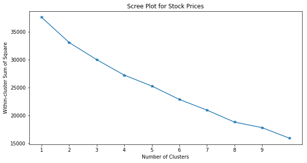

```python
plt.figure(figsize=(10,5))
plt.plot(range(1,11), sum_of_sqr, marker = '*')
plt.title('Scree Plot for Stock Prices')
plt.xlabel('Number of Clusters')
plt.ylabel('Within-cluster Sum of Square')
plt.xticks(np.arange(1, 10, step = 1))
plt.show()
```

**We notice that there are multiple 'Elbows' leading us to take a decision of running all of them by trial and error.**

**Hence we will run the above K-Means with clusters 2, 3, 5 and 8 and evaluate based on the Silhouette score.**

### 2 Cluster approach

```python
cl_2 = KMeans(n_clusters=2, random_state=123).fit(scaled_stocks)
cl_2_prediction = cl_2.predict(scaled_stocks)
np.unique(cl_2_prediction, return_counts=True)
```

```
(array([0, 1]), array([ 1, 38], dtype=int64))
```

```python
silhouette_score(scaled_stocks, cl_2_prediction)
```

```
0.44620080431030995
```

**Silhouette score for 2 Clusters is 0.45.**

### 3 Cluster approach

```python
cl_3 = KMeans(n_clusters=3, random_state=123).fit(scaled_stocks)
cl_3_prediction = cl_3.predict(scaled_stocks)
np.unique(cl_3_prediction, return_counts=True)
```

```
(array([0, 1, 2]), array([37,  1,  1], dtype=int64))
```

```python
silhouette_score(scaled_stocks, cl_3_prediction)
```

```
0.3652459501091916
```

**Silhouette score for 3 Clusters is 0.37.**

### 5 Cluster approach

```python
cl_5 = KMeans(n_clusters=5, random_state=123).fit(scaled_stocks)
cl_5_prediction = cl_5.predict(scaled_stocks)
np.unique(cl_5_prediction, return_counts=True)
```

```
(array([0, 1, 2, 3, 4]), array([ 1, 33,  1,  1,  3], dtype=int64))
```

```python
silhouette_score(scaled_stocks, cl_5_prediction)
```

```
0.3206255740860464
```

**Silhouette score for 5 Clusters is 0.32.**

### 8 cluster approach

```python
cl_8 = KMeans(n_clusters=8, random_state=123).fit(scaled_stocks)
cl_8_prediction = cl_8.predict(scaled_stocks)
np.unique(cl_8_prediction, return_counts=True)
```

```
(array([0, 1, 2, 3, 4, 5, 6, 7]),
 array([ 1, 18, 15,  1,  1,  1,  1,  1], dtype=int64))
```

```python
silhouette_score(scaled_stocks, cl_8_prediction)
```

```
0.13189401038056514
```

**Silhouette score for 8 Clusters is 0.13.**

### Based on the above results, we note that for the given company stock prices dataset, the K-Means clustering algorithm provides multiple 'Optimum' values out of which 2 clusters is optimal based on Silhoutte score.